# Solution to Class 7: Plotting

## Exercise A

The COVID-19 pandemic is gradually fading. We will do some data visualization to help us understand the COVID-19 case count across the globe. For this we will use the data made available by the World Health Organization through the CSV file `WHO-COVID-19-global-data.csv`.

1. Create a new python notebook and name it as your_roll_number_class_7_assign_1.ipynb. You will submit this.
2. Load the WHO-COVID-19-global-data.csv
3. Make a line plot illustrating the global COVID-19 "new case count" as a function of "days since 2020-01-03 (YYYY-MM-DD)"
4. On to the same plot overlay the COVID-19 "new case count" for India, US, and Brasil. Add a legend for each trace.
5. Write three or more (bulletted) observations you make from your plot.
6. (Bonus question) Alongside the trend of increase and decrease in "new case count" on the scale of months, do you notice a fast variation within a week? Can you confirm this fast variation using some mathematical analysis tool? Hint: Use the Fourier transform utility (`np.fft.rfft()`), plot the magnitude Fourier spectrum, and estimate the periodicity from the peak depicted in the spectrum.

```python
import numpy as np
import pandas as pd
import matplotlib as mpl
import matplotlib.pyplot as plt
# General plot parameters
mpl.rcParams['lines.linewidth'] = 1.5
mpl.rcParams['lines.linestyle'] = '-'

mpl.rcParams['font.family'] = 'DejaVu Sans' # this is also the default
mpl.rcParams['font.size'] = 14

mpl.rcParams['xtick.major.size'] = 10
mpl.rcParams['xtick.major.width'] = 2
mpl.rcParams['ytick.major.size'] = 10
mpl.rcParams['ytick.major.width'] = 2

mpl.rcParams['axes.linewidth'] = 2
mpl.rcParams['axes.spines.top'] = False
mpl.rcParams['axes.spines.right'] = False

# stating multiple params in one line
mpl.rcParams.update({"axes.grid" : True, "grid.color": "black", "grid.alpha": 0.3, "grid.linestyle": "--"})
```

```python
# load the CSV data file
df = pd.read_csv('./WHO-COVID-19-global-data.csv')
```

```python
# get the dates
dates = list(df['Date_reported'].unique())

# init variables
new_covid_cases = {}
fatality_covid_cases = {}
labels_countries = ['Global', 'United States of America', 'India', 'Brazil', 'China']
# init a dictionary to hold country data
for key in labels_countries:
    new_covid_cases[key] = []
    fatality_covid_cases[key] = []

# loop on the dates to collect COVID data
for date in dates:
    # making a subset dataframe saves time in the following steps
    df_temp = df[df["Date_reported"] == date]
    # get global count
    new_covid_cases['Global'].append(sum(df_temp[df_temp["Date_reported"]==date]['New_cases']))
    fatality_covid_cases['Global'].append(sum(df_temp[df_temp["Date_reported"]==date]['New_deaths']))

    # get country-wise count
    for key in labels_countries[1:]:
        new_covid_cases[key].append(sum(df_temp[(df_temp["Date_reported"]==date) & (df_temp['Country']==key)]['New_cases']))
        fatality_covid_cases[key].append(sum(df_temp[(df_temp["Date_reported"]==date) & (df_temp['Country']==key)]['New_deaths']))
```

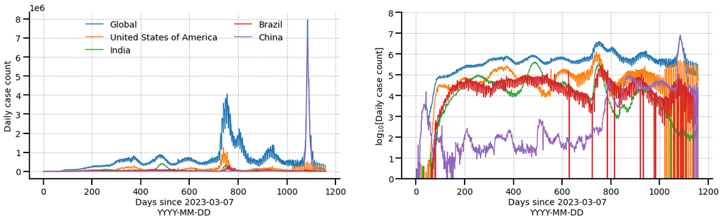

```python
# plot COVID-19 case count
fig, ax = plt.subplots(nrows=1, ncols=2, figsize=[20,5])

for key in labels_countries:

    # remove any 0 or negative entries
    eps = 1e-10
    data_y = [x if x>0 else eps for x in new_covid_cases[key]]
    # plot
    ax[0].plot(data_y, label=key)
    ax[1].plot(np.log10(data_y), label=key)

ax[0].legend(loc='upper center', frameon=False, ncol=2)

ax[0].set_xlabel('Days since ' + dates[-1] + '\nYYYY-MM-DD')
ax[1].set_xlabel('Days since ' + dates[-1] + '\nYYYY-MM-DD')

ax[0].set_ylabel('Daily case count')
ax[1].set_ylabel('$\log_{10}$[Daily case count]')
ax[1].set_ylim(0,8)

plt.show()
```

**Observations**

- All these countries witnessed a similar rise in the initial case count. The lof plot suggests an exponential rise.
- There was often a slow trend of outbursts in infections after a fall in case count.
- After the iniial rise, the case count for Brasil was mostly high and flat. This suggests difficulty in controlling the spread.
- After 900 days, the cases count in India begain rolling down.
- Case count in China saw a slow rise but peaked significantly between 1000-1200 days.

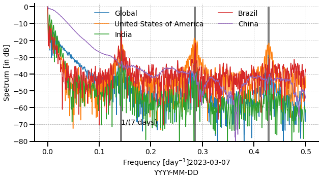

```python
# Bonus question: analyzing the fast fluctiations
fig, ax = plt.subplots(nrows=1, ncols=1, figsize=[10,5])

for key in labels_countries:

    # remove any 0 or negative entries
    eps = 1e-10
    data_y = [x if x>0 else eps for x in new_covid_cases[key]]

    nfft = 4096 # > len(data_y) and power of 2
    Ts = 1 # 1 day
    Fs = 1/Ts
    faxis = np.arange(0, nfft/2+1)/nfft*Fs

    # compute spectrum
    spec_y = np.fft.rfft(data_y, nfft)

    # plot
    ax.plot(faxis, 20*np.log10(abs(spec_y)) - max(20*np.log10(abs(spec_y))), label=key)

ax.legend(loc='upper center', frameon=False, ncol=2)
ax.set_xlabel('Frequency [day$^{-1}$]' + dates[-1] + '\nYYYY-MM-DD')
ax.set_ylabel('Spetrum [in dB]')
ax.vlines(1/7, ymin=-85, ymax=0, color='k', linewidth=4, alpha=0.5)
ax.vlines(2/7, ymin=-85, ymax=0, color='k', linewidth=4, alpha=0.5)
ax.vlines(3/7, ymin=-85, ymax=0, color='k', linewidth=4, alpha=0.5)
ax.set_ylim(-80, 2)
ax.text(1/7, -70, '1/(7 days)')
plt.show()
```

**(Bonus) Observations**

- Most pf the countries, including the global trace, shows fast fluctuations. Computing the Fourier transform of each of the trace (corresponding to new case count) and plotting the spectrum showed peaks in the spectrum at intervals spaced apart by 1/7 per-day.
- This suggests a periodicity in COVID-19 new cases count and this periodicity has a time period of 7 days.
- It may be associated with the decreased cases reporting on weekends. Interestingly this holds for many countries, and hence the pattern in preserved in the global new cases count as well.

## Exercise B

- Use the data in `WHO-COVID-19-global-data.csv` and create a scatter plot of daily COVID-19 new case count between India and Brasil. List your observations.
- Draw a scatter plot between global `New_cases` and `Cummulative_deaths`.
  - Now make three scatter plots within a figure frame (that, is (three columns, one row)). These will correspond to data from 2020, 2021, and 2022 only, respectively.
  - List your obervations

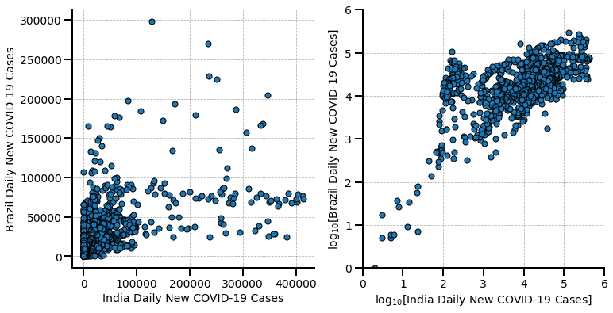

```python
# make the scatter plots
fig, ax = plt.subplots(nrows=1, ncols=2, figsize=[12, 6]) #[len, width] of the frame in inches

# Next we use the second one below
FS = 14 # fontsize
LW = 2 # linewidth
MS = 50 # markersize

# remove any 0 or negative entries
eps = 1e-10
data_y_india = [x if x>0 else eps for x in new_covid_cases['India']]
data_y_brazil = [x if x>0 else eps for x in new_covid_cases['Brazil']]

ax[0].scatter(data_y_india, data_y_brazil, s=MS, edgecolors='black')
ax[0].set_xlabel('India Daily New COVID-19 Cases', fontsize=FS)
ax[0].set_ylabel('Brazil Daily New COVID-19 Cases', fontsize=FS)

ax[1].scatter(np.log10(data_y_india), np.log10(data_y_brazil), s=MS, edgecolors='black')
ax[1].set_xlabel('$\log_{10}$[India Daily New COVID-19 Cases]', fontsize=FS)
ax[1].set_ylabel('$\log_{10}$[Brazil Daily New COVID-19 Cases]', fontsize=FS)
ax[1].set_xlim([0,6])
ax[1].set_ylim([0,6])

plt.show()
```

**Observations**

- Scatter plot on the left shows that there is a cluster. But because of the large dynamic range in variability case count the pattern is not clear.
- logarithmic transformation is one way to scale down the dynamic range of variability. Hence, applying this transformation to the case count might show something meaningful.
- Scatter plot on the right now shows a clear correlation between COVID-19 case count in India and Brazil.

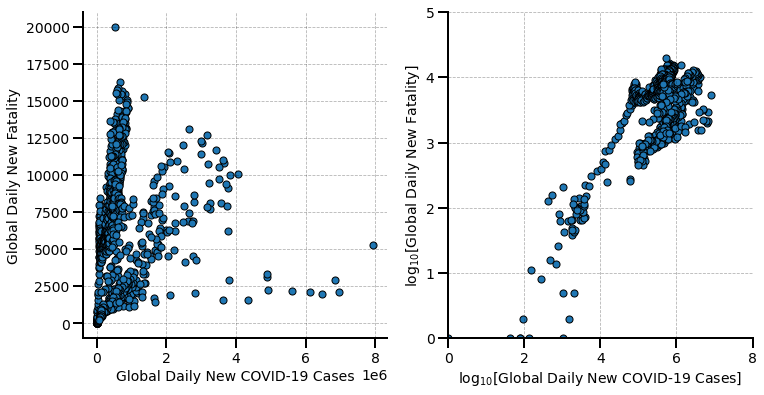

```python
# make additional scatter plots
fig, ax = plt.subplots(nrows=1, ncols=2, figsize=[12, 6]) #[len, width] of the frame in inches

# Next we use the second one below
FS = 14 # fontsize
LW = 2 # linewidth
MS = 50 # markersize

# remove any 0 or negative entries
eps = 1e-10
data_y_case = [x if x>0 else eps for x in new_covid_cases['Global']]
data_y_fatality = [x if x>0 else eps for x in fatality_covid_cases['Global']]

ax[0].scatter(data_y_case, data_y_fatality, s=MS, edgecolors='black')
ax[0].set_xlabel('Global Daily New COVID-19 Cases', fontsize=FS)
ax[0].set_ylabel('Global Daily New Fatality', fontsize=FS)

ax[1].scatter(np.log10(data_y_case), np.log10(data_y_fatality), s=MS, edgecolors='black')
ax[1].set_xlabel('$\log_{10}$[Global Daily New COVID-19 Cases]', fontsize=FS)
ax[1].set_ylabel('$\log_{10}$[Global Daily New Fatality]', fontsize=FS)
ax[1].set_xlim([0,8])
ax[1].set_ylim([0,5])

plt.show()
```

**Observations**

- There is a correlation between new covid case count and the fatalities.

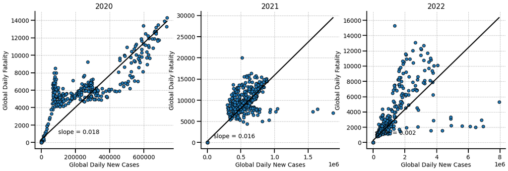

```python
# few more scatter plots
fig, ax = plt.subplots(nrows=1, ncols=3, figsize=[20, 6]) #[len, width] of the frame in inches

# Next we use the second one below
FS = 14 # fontsize
LW = 2 # linewidth
MS = 50 # markersize

# remove any 0 or negative entries
eps = 1e-10

for indx, year in enumerate(['2020', '2021', '2022']):

        df_subset = df[df['Date_reported'].str.contains(year)]
        df_subset = df[df['Date_reported'].str.contains(year)]

        data_y_case = []
        data_y_fatality = []
        for date in dates:
                # making a subset dataframe saves time in the following steps
                df_temp = df_subset[df_subset["Date_reported"] == date]
                # get global count
                data_y_case.append(sum(df_temp[df_temp["Date_reported"]==date]['New_cases']))
                data_y_fatality.append(sum(df_temp[df_temp["Date_reported"]==date]['New_deaths']))

        # remove erroneous/bad values
        data_y_case = [x if x>0 else eps for x in data_y_case]
        data_y_fatality = [x if x>0 else eps for x in data_y_fatality]

        ax[indx].scatter(data_y_case, data_y_fatality, s=MS, edgecolors='black')

        # do better understand the correlation with fit a line
        b, a = np.polyfit(data_y_case, data_y_fatality, deg=1)
        # Create sequence of 100 numbers from 0 to 100
        xseq = np.linspace(0, max(data_y_case), num=100)
        # Plot regression line
        ax[indx].plot(xseq, a + b * xseq, color="k", lw=2.5)
        ax[indx].text(1e5, 1000, 'slope = ' + f"{b:.3f}")

        ax[indx].set_xlabel('Global Daily New Cases', fontsize=FS)
        ax[indx].set_ylabel('Global Daily Fatality', fontsize=FS)
        ax[indx].set_title(year)

plt.show()
```

**Observations**

- For all three there is a correlation
- The correlation is more in 2020 and 2021 than in 2022. This suggests that the severity of panademic was less in 2022.

## Exercise C

- Use the data in `WHO-COVID-19-global-data.csv`
- Create dataframe containing three colums: country code (or name), cummulative covid case count, cummulative covid death count. Using this data frame:
  - Make a scatter plot of cummulative covid case count, cummulative covid death count. List your observations.
  - Make a bar plot illustrating the cummulative case count for top five countries. List your observations.

```python
# init a dictionary
data = {}
data['country'] = []
data['cases'] = []
data['fatality'] = []

countries = df['Country'].unique()

for country in countries:
    data['country'].append(country)
    data['cases'].append(sum(df[df['Country'] == country]['New_cases']))
    data['fatality'].append(sum(df[df['Country'] == country]['New_deaths']))

# convert dictionary to dataframe
df_temp = df.from_dict(data)
df_temp = df_temp.sort_values(by=['cases'], ascending=False)
```

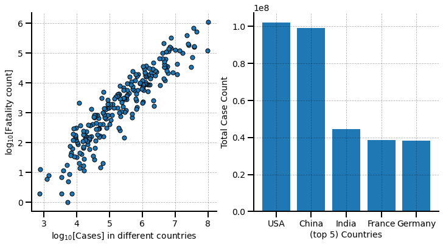

```python
# make scatter and bar plots
fig, ax = plt.subplots(nrows=1, ncols=2, figsize=[12, 6]) #[len, width] of the frame in inches

# Next we use the second one below
FS = 14 # fontsize
LW = 2 # linewidth
MS = 50 # markersize

# remove any 0 or negative entries

ax[0].scatter(np.log10(df_temp['cases']), np.log10(df_temp['fatality']), s=MS, edgecolors='black')
ax[0].set_xlabel('$\log_{10}$[Cases] in different countries', fontsize=FS)
ax[0].set_ylabel('$\log_{10}$[Fatality count]', fontsize=FS)

ax[1].bar(np.arange(5), df_temp['cases'][:5])
ax[1].set_xticks(np.arange(5))
ax[1].set_xticklabels(['USA', 'China', 'India', 'France', 'Germany'], rotation=0, fontsize=FS)
# ax[1].set_xticklabels(df_temp['country'][:5], rotation=0, fontsize=FS)

ax[1].set_xlabel('(top 5) Countries', fontsize=FS)
ax[1].set_ylabel('Total Case Count', fontsize=FS)
# ax[1].set_xlim([0,8])
# ax[1].set_ylim([0,5])

plt.show()
```

## Exercise D

Make a histogram of cummulative COVID-19 case using the new data frame you made. List your observations. Does it look Gaussian? Yes or no and explain why so?

Let's move to the next section now.

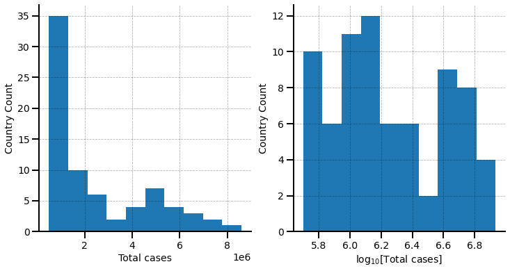

```python
fig, ax = plt.subplots(nrows=1, ncols=2, figsize=[12, 6]) #[len, width] of the frame in inches

# Next we use the second one below
FS = 14 # fontsize
LW = 2 # linewidth
MS = 50 # markersize

# remove any 0 or negative entries
thres_1 = 5e5
thres_2 = 1e7

data_y = df_temp['cases'].values
data_yy = [x for x in data_y if (x> thres_1) & (x< thres_2)]
ax[0].hist(data_yy)
ax[0].set_xlabel('Total cases', fontsize=FS)
ax[0].set_ylabel('Country Count', fontsize=FS)

ax[1].hist(np.log10(data_yy))
ax[1].set_xlabel('$\log_{10}$[Total cases]', fontsize=FS)
ax[1].set_ylabel('Country Count', fontsize=FS)

plt.show()
```

## Exercise: Analyzing Iris dataset

```python
# Import libraries

import matplotlib.pyplot as plt
import pandas as pd
from sklearn import datasets

# Read data from the csv file provided
data = pd.read_csv("iris.csv")

# Check the head of the data
data.head()

# # To get the data from sklearn library (Optional)
# # Get the data
# iris = datasets.load_iris()

# # convert to pandas data frame
# iris_df = pd.DataFrame(data=iris.data,columns=iris.feature_names)

# Optional: to get the species labels as 0, 1 and 2
#species = iris.target
#iris_df['Species'] = species

# Check the data
# iris_df.head()
```

|  | Sepal.Length | Sepal.Width | Petal.Length | Petal.Width | Species |
| --- | --- | --- | --- | --- | --- |
| 0 | 5.1 | 3.5 | 1.4 | 0.2 | setosa |
| 1 | 4.9 | 3.0 | 1.4 | 0.2 | setosa |
| 2 | 4.7 | 3.2 | 1.3 | 0.2 | setosa |
| 3 | 4.6 | 3.1 | 1.5 | 0.2 | setosa |
| 4 | 5.0 | 3.6 | 1.4 | 0.2 | setosa |

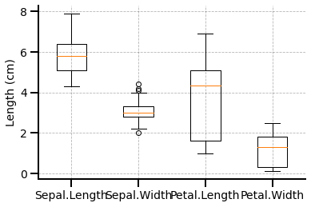

```python
# Drop the Species column
len_width =  data.drop('Species', axis=1)


fig1, axes = plt.subplots()

# Draw the box plot; note that we have to transpose the data
axes.boxplot(len_width)

# Define ticks on horizontal axes
ticks = range(1, len(len_width.columns)+1)

# Define tick labels for the horizontal axes
labels = list(len_width.columns)

# Apply ticks and lables on horizontal axis
axes.set_xticks(ticks)
axes.set_xticklabels(labels)

# Specify Label for the vertical axes
axes.set_ylabel('Length (cm)')

# Show the plot
plt.show()
```

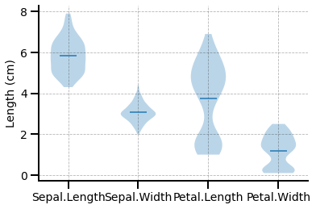

```python
fig2, axes = plt.subplots()

# Draw the box plot; note that we have to transpose the data
axes.violinplot(len_width, showmeans=True, showextrema=False, showmedians=False)

# Define ticks on horizontal axes
ticks = range(1, len(len_width.columns)+1)

# Define tick labels for the horizontal axes
labels = list(len_width.columns)

# Apply ticks and lables on horizontal axis
axes.set_xticks(ticks)
axes.set_xticklabels(labels)

# Specify Label for the vertical axes
axes.set_ylabel('Length (cm)')

# Show the plot
plt.show()
```

**Comparison of the boxplot and the violin plot**

Both the plots show the spread of the data for each feature. However, the violin plot shows that distribution of speal length is very wide and the distributions of petal length and width are largely bi-modal. That means, there are distinctly two types of subpopulations for these two features.

Thank you! The take aways are as follows:

- Plotting is easy in python
- With some care you can make neat plots. Python provides lots of options for tweaking a plot's presentation.
- Analyzing large dataframes can be time taking. Always give some time to think how can you reduce the scanning of the data frame. For example, you can make subsets from the huge dataframe before looping, like we did above.
- Always pay attention to the warnings. It can help you remove some bad data from the dataframe.
- Dynamic range of two variables can be different. This can mask the visibility of correlation. Log transformation can be very helpful.
- Box and violin plots are very useful to get a quick visualization of the some basic statistical properties of (huge) data.

  Hope you enjoyed this exercise ;)!